# Homework 03

## Question 1: Build an `explain-to-me` skill

Create a small skill named `explain-to-me` that helps you understand a homework question.

1. Design your `SKILL.md` file so that, when you explicitly ask your agent to use the skill to read a homework question, the agent communicates with you and explains what the question is asking.
2. Keep the skill file short. It should contain a few useful rules, instructions, and a clear statement of your intent. For example, you may ask the agent to explain the goal of the question, clarify what work is required, and point you to an appropriate section of the Week 3 lectures: [Ridge Regression: Stability Through Shrinkage](https://teazrq.github.io/stat432rpy/topics/ridge-regression/ridge-regression.html) or [From a Penalized Objective to a Fitted Ridge Model](https://teazrq.github.io/stat432rpy/topics/ridge-regression/optimization-and-cross-validation.html). The skill should help you understand the question without completing the solution for you.
3. Create the skill yourself or with the help of AI. Save it as `explain-to-me/SKILL.md`. Then ask your AI agent to install the skill using its normal skill-installation method. Test it by explicitly asking the agent to use `explain-to-me` to read and explain Question 2.
4. If the skill does not work well, or if it begins to disturb your usual workflow, ask your agent to remove the installed skill. You may revise and reinstall it if you wish.
5. In all cases, append the complete contents of your developed `explain-to-me/SKILL.md` file at the end of your Homework 3 submission under the heading **`explain-to-me` skill**.

### Answer

I wrote the skill with the help of my AI agent (Claude Code) and saved it as `explain-to-me/SKILL.md`. The agent installed it with Claude Code’s normal method, by copying the folder into the personal skills directory `~/.claude/skills/explain-to-me/`, where Claude Code discovers skills automatically.

To test it, I explicitly asked the agent to use `explain-to-me` to read and explain Question 2. The skill worked as intended. The agent stated the goal (near-collinearity makes the coefficient *difference* unstable, while ridge trades a little bias for much lower variance). It listed what each part requires: three numbers and an argument in (a), a summary table in (b), and a written interpretation in (c). It flagged setup details that are easy to get wrong: scaling by the mean square rather than `sd()`, generating $\mathbf X$ only once, reusing each $(\mathbf y,\mathbf y^*)$ pair for all three $\lambda$ values, and the $n\lambda$ penalty. It also pointed to the scaling and SVD sections of *Ridge Regression: Stability Through Shrinkage*. It gave no numbers or code, and it ended by asking whether anything was unclear. It did not disturb my usual workflow, so I kept it installed.

The complete `SKILL.md` is appended at the end of this report under the heading **`explain-to-me` skill**.

## Question 2: Ridge regression with nearly collinear predictors

Let $n=100$. Generate mutually independent standard normal random variables

$$L_i, U_{i1}, U_{i2}, X_{i3}, X_{i4},
\qquad i=1,\ldots,n,$$

and define

$$X_{i1}=L_i+0.04U_{i1},
\qquad
X_{i2}=L_i+0.04U_{i2}.$$

Center and standardize each column of $\mathbf X$ to have mean zero and average squared value one, following the [lecture’s scaling convention](https://teazrq.github.io/stat432rpy/topics/ridge-regression/ridge-regression.html#put-every-covariate-on-a-common-scale).

Continue to use $\mathbf X\in\mathbb R^{n\times p}$ for the standardized matrix and keep it fixed throughout the question, where $p=4$ is the number of predictors. The unpenalized intercept gives $p+1=5$ total fitted coefficients. Let

$$\boldsymbol\beta
=
(1.5,1.5,1,0)^{\mathsf T},
\qquad
\boldsymbol\mu
=
\mathbf X\boldsymbol\beta.$$

Generate a training response and an independent test response at the same predictor values:

$$\begin{aligned}
\mathbf y
&=
\boldsymbol\mu+\boldsymbol\epsilon,\\
\mathbf y^*
&=
\boldsymbol\mu+\boldsymbol\epsilon^*,
\end{aligned}$$

where

$$\boldsymbol\epsilon,
\boldsymbol\epsilon^*
\overset{\mathrm{ind}}{\sim}
\mathcal N_n(\mathbf0,\mathbf I_n).$$

Center the training response as $\widetilde{\mathbf y}=\mathbf y-\bar y\mathbf1_n$. For each $\lambda\in\{0,0.02,0.2\}$, fit the slopes using the lecture’s ridge formula:

$$\widehat{\boldsymbol\beta}_\lambda
=
\left(\mathbf X^{\mathsf T}\mathbf X+n\lambda\mathbf I_p\right)^{-1}
\mathbf X^{\mathsf T}\widetilde{\mathbf y}.$$

The unpenalized intercept is $\widehat\beta_0=\bar y$; add this training mean back when predicting either response. The case $\lambda=0$ is ordinary least squares. Use seed `43231` before generating the design and responses. R and Python use different random-number generators, so their exact numerical results need not agree.

1. Generate $\mathbf X$ once. Report the correlation between its first two columns and its largest and smallest singular values. Use these quantities to explain why the estimator contrast $\widehat\beta_1-\widehat\beta_2$ should be much more variable than $\widehat\beta_1+\widehat\beta_2$.
2. Independently repeat the generation of $\mathbf y$ and $\mathbf y^*$, followed by all three fits, 200 times while keeping $\mathbf X$ fixed. Draw the training and test noise inside each repetition, then reuse that realized pair for all three values of $\lambda$. For each value of $\lambda$, report the empirical mean and standard deviation of

$$\widehat\beta_1,
\quad
\widehat\beta_2,
\quad
\widehat\beta_1+\widehat\beta_2,
\quad
\widehat\beta_1-\widehat\beta_2.$$

Also report the average training MSE and the average test MSE calculated from the independent test response, where

$$\operatorname{MSE}_{\mathrm{test}}
=
\frac{1}{n}
\left\lVert
\mathbf y^*
-
\widehat\beta_0\mathbf1_n
-
\mathbf X\widehat{\boldsymbol\beta}
\right\rVert_2^2.$$

3. Interpret the coefficient estimates and test MSE using bias and variance. Explain why ridge can substantially stabilize the individual coefficients without producing an equally large change in the fitted values.

### Answer

**Show the workflow**

```r
set.seed(43231)
n <- 100
p <- 4

L  <- rnorm(n)
U1 <- rnorm(n)
U2 <- rnorm(n)
X3 <- rnorm(n)
X4 <- rnorm(n)

X_raw <- cbind(X1 = L + 0.04 * U1, X2 = L + 0.04 * U2, X3 = X3, X4 = X4)

# lecture convention: mean zero and average squared value one (divide by n)
X_c <- sweep(X_raw, 2, colMeans(X_raw))
X   <- sweep(X_c, 2, sqrt(colMeans(X_c^2)), "/")

beta <- c(1.5, 1.5, 1, 0)
mu   <- drop(X %*% beta)
```

**(a) Correlation and singular values of the fixed design.**

**Show the workflow**

```r
sv <- svd(X)

c(check_mean_sq  = mean(colMeans(X^2)),
  cor_X1_X2      = cor(X[, 1], X[, 2]),
  largest_sv     = max(sv$d),
  smallest_sv    = min(sv$d))
```

```
check_mean_sq     cor_X1_X2    largest_sv   smallest_sv
    1.0000000     0.9977057    14.1414804     0.4753575
```

**Show the workflow**

```r
round(sv$d, 4)
```

```
[1] 14.1415 10.3477  9.6290  0.4754
```

**Show the workflow**

```r
round(sv$v, 3)       # columns are the right singular vectors v_1, ..., v_4
```

```
       [,1]   [,2]   [,3]   [,4]
[1,] -0.706  0.022  0.024  0.707
[2,] -0.706  0.027  0.018 -0.707
[3,] -0.046 -0.701 -0.712  0.001
[4,]  0.004  0.712 -0.702  0.006
```

**Show the workflow**

```r
# OLS standard deviation of c'beta_hat when sigma = 1: sqrt( sum_j (c'v_j)^2 / d_j^2 )
sd_contrast <- function(cvec) sqrt(sum(drop(cvec %*% sv$v)^2 / sv$d^2))
c(theory_sd_sum        = sd_contrast(c(1,  1, 0, 0)),
  theory_sd_difference = sd_contrast(c(1, -1, 0, 0)))
```

```
       theory_sd_sum theory_sd_difference
           0.1001101            2.9750002
```

The first two columns are almost identical, with correlation $0.998$. The largest singular value is $d_{\max}=14.14$ and the smallest is $d_{\min}=0.475$, so $d_{\max}/d_{\min}\approx 30$.

Write $\mathbf X=\mathbf U\mathbf D\mathbf V^{\mathsf T}$. For OLS with $\sigma^2=1$,

$$\operatorname{Var}(\widehat{\boldsymbol\beta}_0)
=(\mathbf X^{\mathsf T}\mathbf X)^{-1}
=\sum_{j=1}^{4}\frac{\mathbf v_j\mathbf v_j^{\mathsf T}}{d_j^2},
\qquad
\operatorname{Var}(\mathbf c^{\mathsf T}\widehat{\boldsymbol\beta}_0)
=\sum_{j=1}^{4}\frac{(\mathbf c^{\mathsf T}\mathbf v_j)^2}{d_j^2}.$$

A direction in coefficient space is estimated precisely when it lines up with a large singular value, and poorly when it lines up with a small one. The printed singular vectors show the following:

- The smallest singular value, $0.475$, belongs to $\mathbf v_4\approx(1,-1,0,0)/\sqrt2$. This is exactly the difference direction, and it is small because $X_1-X_2=0.04(U_1-U_2)$ has almost no spread. The data contain very little information about how the combined effect is split between $X_1$ and $X_2$.
- The largest singular value, $14.14$, belongs to $\mathbf v_1\approx-(1,1,0,0)/\sqrt2$. This is the sum direction, driven by the shared factor $L$, which varies a lot.

So $\operatorname{Var}(\widehat\beta_1-\widehat\beta_2)\approx 2/d_{\min}^2$ while $\operatorname{Var}(\widehat\beta_1+\widehat\beta_2)\approx 2/d_{\max}^2$. The ratio of standard deviations is roughly $d_{\max}/d_{\min}\approx 30$. The exact theoretical values above ($2.98$ versus $0.10$) confirm this.

**(b) Two hundred repetitions with $\mathbf X$ held fixed.**

**Show the workflow**

```r
lambdas <- c(0, 0.02, 0.2)
nsim    <- 200
stats   <- c("beta1", "beta2", "sum", "difference", "train_MSE", "test_MSE")
out     <- array(NA_real_, c(nsim, length(lambdas), length(stats)),
                 dimnames = list(NULL, paste0("lambda=", lambdas), stats))

XtX <- crossprod(X)
for (r in 1:nsim) {
  y      <- mu + rnorm(n)                  # training noise, drawn inside the repetition
  y_star <- mu + rnorm(n)                  # independent test noise
  ybar   <- mean(y)
  Xty    <- crossprod(X, y - ybar)

  for (k in seq_along(lambdas)) {          # same (y, y*) pair for every lambda
    b    <- drop(solve(XtX + n * lambdas[k] * diag(p), Xty))
    yhat <- ybar + drop(X %*% b)
    out[r, k, ] <- c(b[1], b[2], b[1] + b[2], b[1] - b[2],
                     mean((y - yhat)^2), mean((y_star - yhat)^2))
  }
}

coef_mean <- apply(out[, , 1:4], c(2, 3), mean)
coef_sd   <- apply(out[, , 1:4], c(2, 3), sd)
mse_avg   <- apply(out[, , 5:6], c(2, 3), mean)

round(coef_mean, 4)
```

```
             beta1  beta2    sum difference
lambda=0    1.4956 1.5098 3.0054    -0.0142
lambda=0.02 1.4870 1.4892 2.9762    -0.0022
lambda=0.2  1.3679 1.3687 2.7366    -0.0008
```

**Show the workflow**

```r
round(coef_sd, 4)
```

```
             beta1  beta2    sum difference
lambda=0    1.5439 1.5486 0.0951     3.0911
lambda=0.02 0.1615 0.1659 0.0942     0.3136
lambda=0.2  0.0457 0.0473 0.0865     0.0344
```

**Show the workflow**

```r
round(mse_avg, 4)
```

```
            train_MSE test_MSE
lambda=0       0.9648   1.0625
lambda=0.02    0.9747   1.0493
lambda=0.2     1.0768   1.1335
```

Table 1: Empirical mean (standard deviation) over 200 repetitions.

| $\lambda$ | $\widehat\beta_1$ | $\widehat\beta_2$ | $\widehat\beta_1+\widehat\beta_2$ | $\widehat\beta_1-\widehat\beta_2$ | Avg. train MSE | Avg. test MSE |
| --- | --- | --- | --- | --- | --- | --- |
| 0 (OLS) | 1.496 (1.544) | 1.510 (1.549) | 3.005 (0.095) | -0.014 (3.091) | 0.9648 | 1.0625 |
| 0.02 | 1.487 (0.162) | 1.489 (0.166) | 2.976 (0.094) | -0.002 (0.314) | 0.9747 | 1.0493 |
| 0.2 | 1.368 (0.046) | 1.369 (0.047) | 2.737 (0.086) | -0.001 (0.034) | 1.0768 | 1.1335 |

**(c) Bias and variance.**

**Show the workflow**

```r
theta <- drop(t(sv$u) %*% mu)             # true mean in each left singular direction
decomp <- t(sapply(lambdas, function(l) {
  rho <- sv$d^2 / (sv$d^2 + n * l)
  c(lambda       = l,
    rho_sum_dir  = rho[1],
    rho_diff_dir = rho[4],
    bias_sq      = sum((1 - rho)^2 * theta^2) / n,
    variance     = (1 + sum(rho^2)) / n,  # the 1 is the intercept
    expected_test_MSE = 1 + sum((1 - rho)^2 * theta^2) / n + (1 + sum(rho^2)) / n)
}))
round(theta, 3)
```

```
[1] -30.617  -6.484  -6.240   0.000
```

**Show the workflow**

```r
round(decomp, 4)
```

```
     lambda rho_sum_dir rho_diff_dir bias_sq variance expected_test_MSE
[1,]   0.00      1.0000       1.0000  0.0000   0.0500            1.0500
[2,]   0.02      0.9901       0.1015  0.0012   0.0391            1.0404
[3,]   0.20      0.9091       0.0112  0.1002   0.0321            1.1323
```

*Coefficients.* OLS is unbiased: $\widehat\beta_1$ and $\widehat\beta_2$ average close to $1.5$, but each has standard deviation about $1.55$. Almost all of that comes from the difference, whose SD is $3.09$, while the sum is pinned down with SD $0.095$. A single OLS fit could easily report $\widehat\beta_1=3$ and $\widehat\beta_2=0$.

Ridge multiplies the fitted component in direction $j$ by $\rho_j=d_j^2/(d_j^2+n\lambda)$. For the difference direction, $d_4^2=0.226$ is tiny next to $n\lambda$, so $\rho_4$ is $0.10$ at $\lambda=0.02$ and $0.011$ at $\lambda=0.2$. The SD of the difference falls from $3.09$ to $0.31$ and then to $0.034$, and the individual coefficients become about $10$ and $34$ times more stable. This costs almost no bias, because the true difference is $\beta_1-\beta_2=0$: shrinking toward zero moves it toward the truth.

The sum direction has $d_1^2=200$ and is barely touched ($\rho_1=0.99$) at $\lambda=0.02$. At $\lambda=0.2$, however, $\rho_1=0.91$, and the mean of the sum drops from $3.0$ to $2.74$. That is real bias in a direction that carries most of the signal.

*Test MSE.* The table matches the decomposition $1+\text{bias}^2+\text{variance}$:

- OLS has no bias and variance $5/100=0.05$.
- $\lambda=0.02$ removes about $0.01$ of variance (essentially one direction’s worth) and adds only $0.001$ of bias, giving the lowest test MSE.
- $\lambda=0.2$ adds about $0.10$ of squared bias, because it shrinks the well-determined, signal-carrying directions ($\mathbf u_1$ through $\mathbf u_3$, where $|\theta_j|$ is $30.6$, $6.5$, and $6.2$). That outweighs its variance savings, so its test MSE is worse than OLS.

Training MSE rises steadily with $\lambda$, as it must, since OLS minimizes training error.

*Why the coefficients change far more than the fitted values.* A coefficient error $\delta$ along $\mathbf v_j$ changes the fitted values by $\mathbf X\mathbf v_j\delta=d_j\mathbf u_j\delta$. Along $\mathbf v_4$, the OLS coefficient variance is $\sigma^2/d_4^2\approx4.4$, but its effect on the fitted values is scaled back by $d_4^2$, contributing only $\sigma^2=1$ in total, or $1/n=0.01$ to the MSE. That is the same as any other direction. The huge swings in $\widehat\beta_1$ and $\widehat\beta_2$ cancel in $\mathbf X\widehat{\boldsymbol\beta}$ because $X_1\approx X_2$: raising $\widehat\beta_1$ while lowering $\widehat\beta_2$ barely changes predictions at these $\mathbf X$ values. Ridge removes that nearly invisible instability, so it stabilizes the coefficients dramatically but changes prediction error by at most about $1/n$ per shrunken direction. It helps fitted values substantially only when many directions are noisy.

## Question 3: What does ridge regression shrink?

Let $\mathbf X\in\mathbb R^{n\times p}$ be a centered predictor matrix, and let $\widetilde{\mathbf y}\in\mathbb R^n$ be the centered response. Use the supplied predictor scales for this algebraic question; the columns need not have unit variance. Here $p$ counts predictors, $\boldsymbol\beta\in\mathbb R^p$ contains their slopes, and $p+1$ counts all fitted coefficients, including the separately fitted, unpenalized intercept. Ridge regression minimizes

$$L_\lambda(\boldsymbol\beta)
=
\frac{1}{2n}
\left\lVert
\widetilde{\mathbf y}-\mathbf X\boldsymbol\beta
\right\rVert_2^2
+
\frac{\lambda}{2}
\lVert\boldsymbol\beta\rVert_2^2.$$

1. Derive the ridge normal equation

$$\left(
\mathbf X^{\mathsf T}\mathbf X
+n\lambda\mathbf I_p
\right)
\widehat{\boldsymbol\beta}_\lambda
=
\mathbf X^{\mathsf T}\widetilde{\mathbf y}.$$

Explain why it has a unique solution whenever $\lambda>0$, even if $\mathbf X$ is rank deficient or $p>n$.

2. Let

$$\mathbf X
=
\mathbf U_r\mathbf D_r\mathbf V_r^{\mathsf T}$$

be a compact singular value decomposition, where $r=\operatorname{rank}(\mathbf X)$, $\mathbf U_r\in\mathbb R^{n\times r}$, $\mathbf D_r\in\mathbb R^{r\times r}$, and $\mathbf V_r\in\mathbb R^{p\times r}$. Show that ridge multiplies the fitted response component in the $j$th left singular-vector direction, for $j=1,\ldots,r$, by

$$\rho_j(\lambda)
=
\frac{d_j^2}{d_j^2+n\lambda}.$$

Suppose $n=100$, $\lambda=0.01$, and the nonzero singular values are

$$d_1=10,
\qquad
d_2=2,
\qquad
d_3=0.2.$$

Calculate the three shrinkage factors and the total effective degrees of freedom, including the unpenalized intercept:

$$\operatorname{df}_{\mathrm{eff}}(\lambda)
=
1+\sum_{j=1}^3\rho_j(\lambda).$$

3. Which direction receives the strongest shrinkage? Explain why shrinking this direction can reduce prediction variance. Under what circumstance could the same shrinkage produce substantial prediction bias?

### Answer

**(a) The ridge normal equation.**

Expanding the objective,

$$L_\lambda(\boldsymbol\beta)
=\frac{1}{2n}\left(\widetilde{\mathbf y}^{\mathsf T}\widetilde{\mathbf y}
-2\boldsymbol\beta^{\mathsf T}\mathbf X^{\mathsf T}\widetilde{\mathbf y}
+\boldsymbol\beta^{\mathsf T}\mathbf X^{\mathsf T}\mathbf X\boldsymbol\beta\right)
+\frac{\lambda}{2}\boldsymbol\beta^{\mathsf T}\boldsymbol\beta .$$

Using $\nabla_{\boldsymbol\beta}(\boldsymbol\beta^{\mathsf T}\mathbf a)=\mathbf a$ and $\nabla_{\boldsymbol\beta}(\boldsymbol\beta^{\mathsf T}\mathbf M\boldsymbol\beta)=2\mathbf M\boldsymbol\beta$ for symmetric $\mathbf M$,

$$\nabla L_\lambda(\boldsymbol\beta)
=-\frac1n\mathbf X^{\mathsf T}\widetilde{\mathbf y}
+\frac1n\mathbf X^{\mathsf T}\mathbf X\boldsymbol\beta
+\lambda\boldsymbol\beta .$$

Setting the gradient to zero and multiplying by $n$ gives

$$\left(\mathbf X^{\mathsf T}\mathbf X+n\lambda\mathbf I_p\right)\widehat{\boldsymbol\beta}_\lambda
=\mathbf X^{\mathsf T}\widetilde{\mathbf y}.$$

*Uniqueness when $\lambda>0$.* For any nonzero $\mathbf a\in\mathbb R^p$,

$$\mathbf a^{\mathsf T}\left(\mathbf X^{\mathsf T}\mathbf X+n\lambda\mathbf I_p\right)\mathbf a
=\lVert\mathbf X\mathbf a\rVert_2^2+n\lambda\lVert\mathbf a\rVert_2^2
\ \ge\ n\lambda\lVert\mathbf a\rVert_2^2>0 .$$

So $\mathbf X^{\mathsf T}\mathbf X+n\lambda\mathbf I_p$ is positive definite, and therefore invertible. The normal equation has exactly one solution, $\widehat{\boldsymbol\beta}_\lambda=(\mathbf X^{\mathsf T}\mathbf X+n\lambda\mathbf I_p)^{-1}\mathbf X^{\mathsf T}\widetilde{\mathbf y}$. The same matrix divided by $n$ is the Hessian of $L_\lambda$, so the objective is strictly convex, and this stationary point is its unique global minimizer.

Nothing in the argument used the rank of $\mathbf X$. When $\mathbf X$ is rank deficient or $p>n$, there are nonzero $\mathbf a$ with $\mathbf X\mathbf a=\mathbf 0$. Then $\mathbf X^{\mathsf T}\mathbf X$ alone is singular, and OLS has infinitely many solutions. The penalty term $n\lambda\lVert\mathbf a\rVert_2^2$ is still strictly positive in those directions, so it breaks the tie. Equivalently, the eigenvalues of $\mathbf X^{\mathsf T}\mathbf X$ are all $\ge 0$, and adding $n\lambda$ lifts every one of them to at least $n\lambda>0$.

**(b) Shrinkage in the singular-vector directions.**

Let $\mathbf X=\mathbf U_r\mathbf D_r\mathbf V_r^{\mathsf T}$ with $\mathbf U_r^{\mathsf T}\mathbf U_r=\mathbf V_r^{\mathsf T}\mathbf V_r=\mathbf I_r$. I claim

$$\widehat{\boldsymbol\beta}_\lambda
=\mathbf V_r\left(\mathbf D_r^2+n\lambda\mathbf I_r\right)^{-1}\mathbf D_r\mathbf U_r^{\mathsf T}\widetilde{\mathbf y}.$$

To check, substitute $\mathbf X^{\mathsf T}\mathbf X=\mathbf V_r\mathbf D_r^2\mathbf V_r^{\mathsf T}$ into the left side of the normal equation:

$$\left(\mathbf V_r\mathbf D_r^2\mathbf V_r^{\mathsf T}+n\lambda\mathbf I_p\right)\mathbf V_r\left(\mathbf D_r^2+n\lambda\mathbf I_r\right)^{-1}\mathbf D_r\mathbf U_r^{\mathsf T}\widetilde{\mathbf y}
=\mathbf V_r\left(\mathbf D_r^2+n\lambda\mathbf I_r\right)\left(\mathbf D_r^2+n\lambda\mathbf I_r\right)^{-1}\mathbf D_r\mathbf U_r^{\mathsf T}\widetilde{\mathbf y}
=\mathbf V_r\mathbf D_r\mathbf U_r^{\mathsf T}\widetilde{\mathbf y}
=\mathbf X^{\mathsf T}\widetilde{\mathbf y}.$$

By the uniqueness in (a), this is the ridge solution. The fitted values are

$$\mathbf X\widehat{\boldsymbol\beta}_\lambda
=\mathbf U_r\mathbf D_r\mathbf V_r^{\mathsf T}\mathbf V_r\left(\mathbf D_r^2+n\lambda\mathbf I_r\right)^{-1}\mathbf D_r\mathbf U_r^{\mathsf T}\widetilde{\mathbf y}
=\sum_{j=1}^{r}\frac{d_j^2}{d_j^2+n\lambda}\,\mathbf u_j\left(\mathbf u_j^{\mathsf T}\widetilde{\mathbf y}\right).$$

The unpenalized ($\lambda=0$) least-squares fit is the projection onto the column space of $\mathbf X$, $\sum_{j=1}^r\mathbf u_j(\mathbf u_j^{\mathsf T}\widetilde{\mathbf y})$. Ridge therefore keeps the same directions $\mathbf u_j$ and multiplies the fitted component along each one by

$$\rho_j(\lambda)=\frac{d_j^2}{d_j^2+n\lambda}\in(0,1].$$

*Numerical case.* With $n=100$ and $\lambda=0.01$, $n\lambda=1$:

**Show the workflow**

```r
n_q3 <- 100; lambda_q3 <- 0.01
d <- c(10, 2, 0.2)
rho <- d^2 / (d^2 + n_q3 * lambda_q3)
round(c(rho, df_eff = 1 + sum(rho)), 4)
```

```
                     df_eff
0.9901 0.8000 0.0385 2.8286
```

$$\rho_1=\frac{100}{101}=0.9901,\qquad
\rho_2=\frac{4}{5}=0.8000,\qquad
\rho_3=\frac{0.04}{1.04}=0.0385,$$

$$\operatorname{df}_{\mathrm{eff}}(0.01)=1+0.9901+0.8000+0.0385=2.8286 .$$

The model is fitting about $2.83$ effective parameters instead of the $r+1=4$ that least squares would use.

**(c) Where the shrinkage is strongest, and what it costs.**

The third direction, $\mathbf u_3$, is shrunk most strongly: only $3.85\%$ of that component survives. It belongs to the smallest singular value $d_3=0.2$. Since $d_j^2/n$ is the sample variance of the predictor combination $\mathbf X\mathbf v_j$, this is the linear combination of predictors that barely varies in the data.

*Why this reduces variance.* Write $\widetilde{\mathbf y}=\boldsymbol\mu+\boldsymbol\epsilon$ (centered), with noise variance $\sigma^2$, and let $\theta_j=\mathbf u_j^{\mathsf T}\boldsymbol\mu$. Because the $\mathbf u_j$ are orthonormal, the fitted component along $\mathbf u_j$ is $\rho_j(\theta_j+\mathbf u_j^{\mathsf T}\boldsymbol\epsilon)$. Its noise part has variance $\rho_j^2\sigma^2$, and its squared bias is $(1-\rho_j)^2\theta_j^2$. Every direction brings a full $\sigma^2$ of noise into the least-squares fit, regardless of $d_j$. But a low-variance direction usually carries little signal, so $\theta_3$ is typically small, and that fitted component is mostly noise. Shrinking it by $\rho_3=0.0385$ cuts its variance from $\sigma^2$ to $0.0015\sigma^2$. The same logic explains the instability in coefficient space: estimating a slope along $\mathbf v_3$ means dividing by $d_3$, so noise is amplified by $1/d_3=5$.

*When it causes substantial bias.* The squared bias in that direction is $(1-\rho_3)^2\theta_3^2\approx0.925\,\theta_3^2$. It is large when the true mean has a large component along $\mathbf u_3$, meaning the response genuinely depends on the predictor combination that has little spread in the sample. An example is a response driven by the *difference* of two highly correlated predictors. Shrinkage helps that direction only if $\rho_3^2\sigma^2+(1-\rho_3)^2\theta_3^2<\sigma^2$, which requires roughly $\theta_3^2\lesssim\sigma^2$. If $|\theta_3|$ is well above $\sigma$, ridge discards real signal and its prediction bias can exceed the variance it saves. Ridge implicitly assumes that signal lives in the high-variance directions of $\mathbf X$, and it is penalized when that assumption fails.

## Question 4: Ridge regression and optimization

Let $\mathbf X\in\mathbb R^{n\times p}$ be a centered predictor matrix with $p=2$. Its columns need not have unit variance in this question. The intercept is fitted separately and is not penalized. Suppose the two eigenvalues of

$$\mathbf A_0
=
\frac{1}{n}\mathbf X^{\mathsf T}\mathbf X$$

are $9$ and $0.01$. Ridge regression with $\lambda=0.09$ has curvature matrix

$$\mathbf A_\lambda
=
\frac{1}{n}\mathbf X^{\mathsf T}\mathbf X
+
\lambda\mathbf I_p.$$

1. Calculate the condition numbers of $\mathbf A_0$ and $\mathbf A_\lambda$. Explain what the change says about the geometry of the ridge objective.
2. Gradient descent uses

$$\boldsymbol\beta^{(k+1)}
=
\boldsymbol\beta^{(k)}
-
\eta\nabla L_\lambda\!\left(\boldsymbol\beta^{(k)}\right).$$

Let $\widehat{\boldsymbol\beta}_\lambda$ be the ridge minimizer and define the optimization error

$$\mathbf e^{(k)}
=
\boldsymbol\beta^{(k)}
-
\widehat{\boldsymbol\beta}_\lambda.$$

Show that the component of $\mathbf e^{(k)}$ in an eigendirection with unpenalized eigenvalue $a$ is multiplied at each step by

$$1-\eta(a+\lambda).$$

Let $M=9.09$, the largest eigenvalue of $\mathbf A_\lambda$. Find the interval of step sizes that contracts every eigendirection. Then compare these two choices:

- For $\eta=1/M$, calculate the two contraction factors and explain which direction converges faster.
- For $\eta=2.1/M$, determine whether the method converges. Assume the initial error has a nonzero component in the eigendirection corresponding to $M$.
3. Increasing $\lambda$ generally improves the condition number. Explain why choosing $\lambda$ to make gradient descent converge as quickly as possible is not a valid statistical tuning rule.

### Answer

**(a) Condition numbers.**

$\mathbf A_0$ and $\mathbf A_\lambda=\mathbf A_0+\lambda\mathbf I_p$ share eigenvectors, and adding $\lambda\mathbf I_p$ adds $\lambda$ to every eigenvalue. So the eigenvalues of $\mathbf A_{0.09}$ are $9.09$ and $0.10$.

$$\kappa(\mathbf A_0)=\frac{9}{0.01}=900,
\qquad
\kappa(\mathbf A_{0.09})=\frac{9.09}{0.10}=90.9 .$$

**Show the workflow**

```r
ev0 <- c(9, 0.01); lambda_q4 <- 0.09
evl <- ev0 + lambda_q4
c(kappa_A0 = max(ev0) / min(ev0), kappa_Alambda = max(evl) / min(evl))
```

```
     kappa_A0 kappa_Alambda
        900.0          90.9
```

The objective is a quadratic bowl whose curvature along each eigendirection equals that eigenvalue. Its level sets are ellipses whose axis lengths scale like $1/\sqrt{\text{eigenvalue}}$, so the ratio of the longest to the shortest axis is $\sqrt\kappa$. Unpenalized, that ratio is $30$: a long, narrow, nearly flat valley in which the loss hardly changes along the weak direction. This is the geometry of an ill-determined coefficient. The penalty adds the same curvature $\lambda$ in every direction. It barely affects the steep direction but increases the flat one tenfold, cutting the aspect ratio to $\sqrt{90.9}\approx9.5$. The bowl is rounder, its minimum is better defined, and it sits closer to the origin.

**(b) Gradient descent.**

From Question 3(a), $\nabla L_\lambda(\boldsymbol\beta)=\mathbf A_\lambda\boldsymbol\beta-\frac1n\mathbf X^{\mathsf T}\widetilde{\mathbf y}$. At the minimizer, $\mathbf A_\lambda\widehat{\boldsymbol\beta}_\lambda=\frac1n\mathbf X^{\mathsf T}\widetilde{\mathbf y}$, so $\nabla L_\lambda(\boldsymbol\beta)=\mathbf A_\lambda(\boldsymbol\beta-\widehat{\boldsymbol\beta}_\lambda)$. Subtracting $\widehat{\boldsymbol\beta}_\lambda$ from both sides of the update gives

$$\mathbf e^{(k+1)}=\mathbf e^{(k)}-\eta\mathbf A_\lambda\mathbf e^{(k)}=\left(\mathbf I_p-\eta\mathbf A_\lambda\right)\mathbf e^{(k)} .$$

Let $\mathbf q$ be a unit eigenvector of $\mathbf A_0$ with eigenvalue $a$. Then $\mathbf A_\lambda\mathbf q=(a+\lambda)\mathbf q$. Because $\mathbf A_\lambda$ is symmetric, $\mathbf q^{\mathsf T}\mathbf A_\lambda=(a+\lambda)\mathbf q^{\mathsf T}$, and so

$$\mathbf q^{\mathsf T}\mathbf e^{(k+1)}
=\mathbf q^{\mathsf T}\mathbf e^{(k)}-\eta(a+\lambda)\,\mathbf q^{\mathsf T}\mathbf e^{(k)}
=\left\{1-\eta(a+\lambda)\right\}\mathbf q^{\mathsf T}\mathbf e^{(k)} .$$

Each step multiplies that component by $1-\eta(a+\lambda)$, and after $k$ steps it has been multiplied by $\{1-\eta(a+\lambda)\}^k$.

*Step sizes that contract every direction.* We need $|1-\eta(a+\lambda)|<1$, i.e. $0<\eta(a+\lambda)<2$, for both eigenvalues $a+\lambda\in\{9.09,\,0.10\}$. The binding constraint is the largest one, $M=9.09$:

$$0<\eta<\frac{2}{M}=\frac{2}{9.09}\approx0.2200 .$$

**Show the workflow**

```r
M <- max(evl)
factor <- function(eta) 1 - eta * evl
rbind(eta_1_over_M   = factor(1 / M),
      eta_2.1_over_M = factor(2.1 / M))
```

```
               [,1]      [,2]
eta_1_over_M    0.0 0.9889989
eta_2.1_over_M -1.1 0.9768977
```

**Show the workflow**

```r
c(upper_step_size = 2 / M)
```

```
upper_step_size
       0.220022
```

- **$\eta=1/M\approx0.110$.** The factors are $1-9.09/9.09=0$ in the steep direction ($a=9$) and $1-0.10/9.09=0.989$ in the flat direction ($a=0.01$). The steep direction converges fastest; its error is eliminated completely in a single step. The flat direction loses only about $1.1\%$ of its error per step and needs roughly $\log(0.01)/\log(0.989)\approx417$ iterations to reduce its error a hundredfold. Overall convergence is governed by the slow direction, which is why the condition number $\kappa=90.9$ measures difficulty.
- **$\eta=2.1/M\approx0.231$.** The factor in the steep direction is $1-2.1=-1.1$, with magnitude greater than $1$. The flat direction’s factor is $0.977$ and still contracts, but the error component along the $M$ direction flips sign and grows by $10\%$ every step: $(-1.1)^k\to\infty$ in magnitude. Since the initial error has a nonzero component there, gradient descent **diverges**.

**(c) Why fast convergence is not a tuning rule.**

$\lambda$ determines *which* estimator is computed, while the optimizer only determines *how quickly* we reach it. These are separate questions. Convergence speed is a property of the numerical procedure. It says nothing about the bias and variance of $\widehat{\boldsymbol\beta}_\lambda$ or its prediction error on new data, which is the statistical purpose of choosing $\lambda$.

Chasing the best condition number pushes $\lambda$ as high as possible: $\kappa(\mathbf A_\lambda)=(9+\lambda)/(0.01+\lambda)\to1$ as $\lambda\to\infty$. But then every $\rho_j\to0$ and $\widehat{\boldsymbol\beta}_\lambda\to\mathbf 0$, which gives a model that converges instantly to a useless, maximally biased answer.

The computational difficulty also has other remedies that leave the estimator unchanged: run more iterations, use a closed-form or Cholesky solution, precondition, or use a method such as conjugate gradients. Once a value is chosen, $\lambda$ changes the model, and it should be chosen by an estimate of out-of-sample error such as cross-validation or GCV, as in Question 5.

## Question 5: Selecting the ridge penalty for real-estate prediction

The supplied `data/realestate.csv` contains 414 real-estate transactions from Sindian District, New Taipei City, Taiwan. The quantitative response `price` is the unit house price. The six predictors are the transaction date, house age, distance to the nearest mass rapid transit station, number of nearby convenience stores, latitude, and longitude. Treat all six predictors as quantitative in this question. The column `row_id` identifies an observation and must not be used as a predictor.

The file `data/realestate-split-folds.csv` assigns 332 observations to the training set and 82 observations to the final test set. It also gives ten fold labels for the training observations. Match the two files using `row_id` and do not use the test responses while selecting a model.

Use the penalty grid

$$\Lambda
=
\{0\}
\mathbin{\cup}
\left\{
10^{-4+0.05l}:l=0,\ldots,120
\right\}.$$

For every fit, center and standardize each predictor using only the observations available to that fit, with the variance divided by the number of fitting observations. Center the response and leave the intercept unpenalized.

1. Perform ten-fold cross-validation over $\Lambda$ using the supplied training folds. Estimate the predictor means and scales separately within each set of nine training folds. For each $\lambda$, calculate the mean validation MSE and $\operatorname{SE}(\lambda)$, the sample standard deviation of the ten fold errors divided by $\sqrt{10}$. Use this SE for the conventional one-standard-error heuristic. Plot the mean validation MSE and identify $\lambda_{\min}$. Choose $\lambda_{\mathrm{1se}}$ as the largest candidate in $\Lambda$, including OLS, satisfying

$$\overline{\operatorname{MSE}}(\lambda)
\leq
\overline{\operatorname{MSE}}(\lambda_{\min})
+
\operatorname{SE}(\lambda_{\min}).$$

2. Use all $n=332$ training observations to calculate the [lecture’s GCV criterion](https://teazrq.github.io/stat432rpy/topics/ridge-regression/optimization-and-cross-validation.html#loocv-and-gcv) for each $\lambda\in\Lambda$:

$$\operatorname{GCV}(\lambda)
=
\frac{
\operatorname{MSE}_{\mathrm{train}}(\lambda)
}{
\left\{
1-\operatorname{df}_{\mathrm{eff}}(\lambda)/n
\right\}^2
}.$$

Here $\operatorname{MSE}_{\mathrm{train}}$ is the training MSE, and $\operatorname{df}_{\mathrm{eff}}$ includes the unpenalized intercept, as in Question 3. Estimate means and scales once from all training observations and keep them fixed for this calculation. Plot the GCV curve and identify $\lambda_{\mathrm{GCV}}$.

3. Fix all three choices before examining the test responses. Refit OLS and ridge at $\lambda_{\min}$, $\lambda_{\mathrm{1se}}$, and $\lambda_{\mathrm{GCV}}$ using all training observations. Report each model’s training MSE, test MSE, and effective degrees of freedom. Interpret the differences and explain why the model with the smallest observed test MSE must not be selected after viewing this table.

**TipStarter workflow**

After matching the two files by `row_id`, use this order:

```
for each validation fold:
    estimate predictor means and scales from the other nine folds
    for each lambda:
        fit on those nine folds and record validation MSE
summarize the ten fold errors and fix lambda_min and lambda_1se
compute GCV using all training observations and fix lambda_GCV
only then refit the four reported models and evaluate the test responses
```

### Answer

**Show the workflow**

```r
realestate <- read.csv("data/realestate.csv")
split_info <- read.csv("data/realestate-split-folds.csv")
dat <- merge(realestate, split_info, by = "row_id")   # matched by row_id

predictors <- c("date", "age", "distance", "stores", "latitude", "longitude")
train <- dat[dat$split == "train", ]
test  <- dat[dat$split == "test", ]
c(n_train = nrow(train), n_test = nrow(test))
```

```
n_train  n_test
    332      82
```

**Show the workflow**

```r
table(train$cv_fold)
```

```
 1  2  3  4  5  6  7  8  9 10
34 34 33 33 33 33 33 33 33 33
```

**Show the workflow**

```r
X_train <- as.matrix(train[, predictors]); y_train <- train$price
X_test  <- as.matrix(test[, predictors]);  y_test  <- test$price

lambda_grid <- c(0, 10^(-4 + 0.05 * 0:120))
length(lambda_grid)
```

```
[1] 122
```

**Show the workflow**

```r
# Fit ridge for every lambda using ONLY the rows passed in: means and scales
# (variance divided by the number of fitting rows) come from those rows alone.
ridge_path <- function(X, y, lambdas) {
  center <- colMeans(X)
  X_c    <- sweep(X, 2, center)
  scale  <- sqrt(colMeans(X_c^2))
  Z      <- sweep(X_c, 2, scale, "/")
  n_fit  <- nrow(Z)
  ybar   <- mean(y)
  ZtZ    <- crossprod(Z)
  Zty    <- crossprod(Z, y - ybar)
  B      <- sapply(lambdas, function(l) solve(ZtZ + n_fit * l * diag(ncol(Z)), Zty))
  d      <- svd(Z)$d
  df     <- 1 + sapply(lambdas, function(l) sum(d^2 / (d^2 + n_fit * l)))
  list(center = center, scale = scale, intercept = ybar, B = B, df = df)
}

# predictions for every lambda (one column per lambda); new rows use the fit's centering/scaling
ridge_predict <- function(fit, X_new) {
  Z_new <- sweep(sweep(X_new, 2, fit$center), 2, fit$scale, "/")
  fit$intercept + Z_new %*% fit$B
}
```

**(a) Ten-fold cross-validation.**

**Show the workflow**

```r
fold_mse <- sapply(1:10, function(k) {
  hold <- train$cv_fold == k
  fit  <- ridge_path(X_train[!hold, ], y_train[!hold], lambda_grid)   # nine folds only
  colMeans((y_train[hold] - ridge_predict(fit, X_train[hold, , drop = FALSE]))^2)
})                                          # rows = lambda, columns = fold

cv_mean <- rowMeans(fold_mse)
cv_se   <- apply(fold_mse, 1, sd) / sqrt(10)

i_min <- which.min(cv_mean)
i_1se <- max(which(cv_mean <= cv_mean[i_min] + cv_se[i_min]))   # largest qualifying lambda

lambda_min <- lambda_grid[i_min]
lambda_1se <- lambda_grid[i_1se]

c(lambda_min = lambda_min, cv_mse_min = cv_mean[i_min], se_min = cv_se[i_min],
  threshold  = cv_mean[i_min] + cv_se[i_min],
  lambda_1se = lambda_1se, cv_mse_1se = cv_mean[i_1se],
  cv_mse_OLS = cv_mean[1])
```

```
  lambda_min   cv_mse_min       se_min    threshold   lambda_1se   cv_mse_1se
  0.01995262  82.97764939  19.22991373 102.20756312   1.58489319 101.59553175
  cv_mse_OLS
 83.01238698
```

**Show the workflow**

```r
round(fold_mse[i_min, ], 1)                 # the ten fold errors at lambda_min
```

```
 [1]  64.9 100.2  33.5  76.6  66.2  36.6 246.0  50.7  72.7  82.4
```

**Show the workflow**

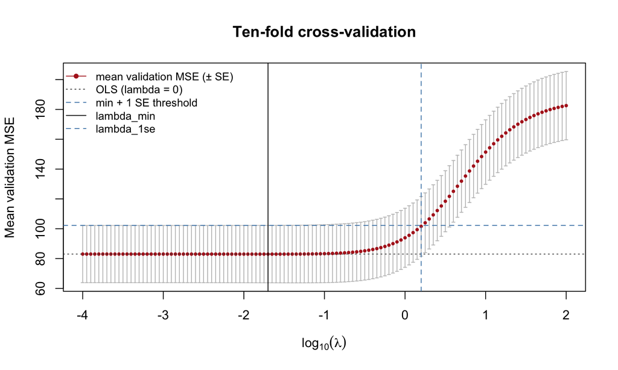

```r
pos <- -1                                   # drop lambda = 0 from the log axis
ll  <- log10(lambda_grid[pos])
plot(ll, cv_mean[pos], type = "n",
     ylim = range(c(cv_mean[pos] - cv_se[pos], cv_mean[pos] + cv_se[pos])),
     xlab = expression(log[10](lambda)), ylab = "Mean validation MSE",
     main = "Ten-fold cross-validation")
arrows(ll, cv_mean[pos] - cv_se[pos], ll, cv_mean[pos] + cv_se[pos],
       angle = 90, code = 3, length = 0.02, col = "grey75")
lines(ll, cv_mean[pos], type = "b", pch = 16, cex = 0.6, col = "firebrick")
abline(h = cv_mean[1], lty = 3, col = "grey30")
abline(h = cv_mean[i_min] + cv_se[i_min], lty = 2, col = "steelblue")
abline(v = log10(c(lambda_min, lambda_1se)), lty = c(1, 2), col = c("black", "steelblue"))
legend("topleft", bty = "n", cex = 0.85,
       legend = c("mean validation MSE (± SE)", "OLS (lambda = 0)",
                  "min + 1 SE threshold", "lambda_min", "lambda_1se"),
       col = c("firebrick", "grey30", "steelblue", "black", "steelblue"),
       lty = c(1, 3, 2, 1, 2), pch = c(16, NA, NA, NA, NA))
```

The validation curve is essentially flat from $\lambda=0$ (OLS) up to about $\lambda\approx0.1$, then rises steeply once shrinkage removes real signal. The minimum is at $\lambda_{\min}=0.01995$ ($\log_{10}\lambda=-1.7$), with mean validation MSE $82.98$. That is barely below OLS at $83.01$.

The standard error at $\lambda_{\min}$ is large, $19.23$, mainly because one fold is very different from the others. Fold 7 has validation MSE $246$ versus roughly $34$–$100$ for the rest, since it contains the most extreme price in the training data ($117.5$, far above the next highest of $78.3$). The one-standard-error threshold is therefore about $102.2$. The largest grid value meeting it is $\lambda_{\mathrm{1se}}=1.585$ ($\log_{10}\lambda=0.2$), a far more heavily penalized model.

**(b) Generalized cross-validation.**

**Show the workflow**

```r
fit_all   <- ridge_path(X_train, y_train, lambda_grid)   # scales fixed from all 332 rows
n_tr      <- nrow(X_train)
train_mse <- colMeans((y_train - ridge_predict(fit_all, X_train))^2)
gcv       <- train_mse / (1 - fit_all$df / n_tr)^2

i_gcv      <- which.min(gcv)
lambda_gcv <- lambda_grid[i_gcv]
c(lambda_gcv = lambda_gcv, gcv_min = gcv[i_gcv], df_eff = fit_all$df[i_gcv],
  gcv_OLS = gcv[1])
```

```
 lambda_gcv     gcv_min      df_eff     gcv_OLS
 0.02818383 83.50191402  6.68865672 83.58127280
```

**Show the workflow**

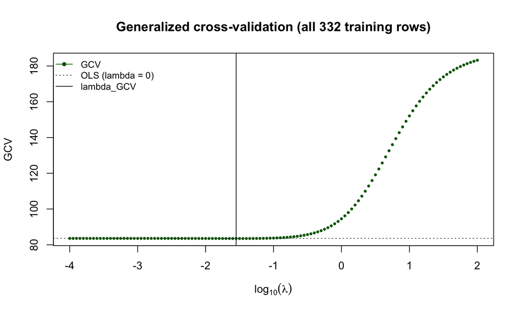

```r
plot(log10(lambda_grid[pos]), gcv[pos], type = "b", pch = 16, cex = 0.6, col = "darkgreen",
     xlab = expression(log[10](lambda)), ylab = "GCV",
     main = "Generalized cross-validation (all 332 training rows)")
abline(h = gcv[1], lty = 3, col = "grey30")
abline(v = log10(lambda_gcv), lty = 1)
legend("topleft", bty = "n", cex = 0.85,
       legend = c("GCV", "OLS (lambda = 0)", "lambda_GCV"),
       col = c("darkgreen", "grey30", "black"), lty = c(1, 3, 1), pch = c(16, NA, NA))
```

GCV has the same shape as the cross-validation curve: flat near OLS, then rising sharply. It is minimized at $\lambda_{\mathrm{GCV}}=0.02818$ ($\log_{10}\lambda=-1.55$), with $\operatorname{GCV}=83.5$ and $\operatorname{df}_{\mathrm{eff}}=6.69$. This is very close to $\lambda_{\min}$ from ten-fold CV.

**(c) Final refits and test evaluation.**

All three penalties, $\lambda_{\min}$, $\lambda_{\mathrm{1se}}$, and $\lambda_{\mathrm{GCV}}$, were fixed in (a) and (b) above. Only now are the test responses used.

**Show the workflow**

```r
chosen  <- c(OLS = 1, lambda_min = i_min, lambda_1se = i_1se, lambda_GCV = i_gcv)
test_mse_all <- colMeans((y_test - ridge_predict(fit_all, X_test))^2)

final_table <- data.frame(
  lambda    = lambda_grid[chosen],
  train_MSE = train_mse[chosen],
  test_MSE  = test_mse_all[chosen],
  df_eff    = fit_all$df[chosen],
  row.names = names(chosen))
round(final_table, 4)
```

```
           lambda train_MSE test_MSE df_eff
OLS        0.0000   80.0939  66.3225 7.0000
lambda_min 0.0200   80.1354  65.9996 6.7732
lambda_1se 1.5849  100.3736  81.1998 3.0329
lambda_GCV 0.0282   80.1713  65.9028 6.6887
```

**Show the workflow**

```r
# how noisy is a test MSE on 82 rows?
sq_err <- (y_test - ridge_predict(fit_all, X_test))^2
c(se_of_test_MSE_at_lambda_min = sd(sq_err[, i_min]) / sqrt(nrow(X_test)),
  se_of_diff_GCV_vs_OLS        = sd(sq_err[, i_gcv] - sq_err[, 1]) / sqrt(nrow(X_test)))
```

```
se_of_test_MSE_at_lambda_min        se_of_diff_GCV_vs_OLS
                   11.476080                     0.453642
```

Table 2: All four models refit on the 332 training observations.

| Model | $\lambda$ | Training MSE | Test MSE | $\operatorname{df}_{\mathrm{eff}}$ |
| --- | --- | --- | --- | --- |
| OLS | 0 | 80.09 | 66.32 | 7.00 |
| Ridge, $\lambda_{\min}$ | 0.01995 | 80.14 | 66.00 | 6.77 |
| Ridge, $\lambda_{\mathrm{1se}}$ | 1.585 | 100.37 | 81.20 | 3.03 |
| Ridge, $\lambda_{\mathrm{GCV}}$ | 0.02818 | 80.17 | 65.90 | 6.69 |

*Interpretation.* OLS, $\lambda_{\min}$, and $\lambda_{\mathrm{GCV}}$ are nearly the same model. Their effective degrees of freedom are $7$, $6.77$, and $6.69$; their training MSEs agree to within $0.1$; and their test MSEs agree to within $0.5$. With six predictors, $332$ observations, and only moderate correlation (the largest is $-0.81$, between distance and longitude), OLS is not very unstable here. A light penalty trims a little variance at a negligible cost in bias, which is what both CV and GCV found.

$\lambda_{\mathrm{1se}}$ is a very different model. Shrinking to about $3$ effective degrees of freedom raises training MSE from $80$ to $100$ and test MSE from about $66$ to $81$: it is underfitting, and the added bias is visible. The one-standard-error rule deliberately favors a simpler model whose CV error is within noise of the best. Here, the noise estimate was inflated by the single outlying fold, which let the rule accept a substantial loss in accuracy.

Test MSE is below training MSE for every model. The $82$ test observations happen to be easier to predict, for example because they lack an extreme price like $117.5$. This is a feature of this particular split, not evidence of a problem with the fits.

*Why the best test MSE must not be chosen now.* The test set’s only role is to give an unbiased estimate of performance for a model that was chosen *without* it. If I now picked $\lambda_{\mathrm{GCV}}$ because it has the smallest number in the table, the test responses would have become part of the selection procedure. The reported $65.90$ would then be the minimum of several noisy estimates, which is biased downward: the winner’s curse.

The differences are also far too small to mean anything. A test MSE computed on $82$ rows has a standard error of about $11.5$, and even the paired difference between $\lambda_{\mathrm{GCV}}$ and OLS has a standard error of about $0.45$, the same size as the gap itself. Choosing on these numbers selects mostly on luck. The choice among the three rules has to rest on the training-data criteria and the reasoning fixed in advance. The table reports how each pre-specified model performed; it cannot be used to pick one.

## Reference

The real-estate data come from I-Cheng Yeh’s [Real Estate Valuation dataset](https://archive.ics.uci.edu/dataset/477/real%2Bestate%2Bvaluation%2Bda) in the UCI Machine Learning Repository. The distributed data retain the original observations and add only the course train-test and fold assignments.

## `explain-to-me` skill

```markdown
---
name: explain-to-me
description: Explain what a STAT 432 homework question is asking, without solving it. Use only when the student explicitly asks to use explain-to-me on a homework question.
---

# explain-to-me

**Intent:** I want to understand a homework question well enough to solve it myself. Help me see what is being asked. Do not do the work for me.

## Instructions

1. Read the requested question in full, including every part (a, b, c, ...) and any linked lecture section.
2. Explain, in plain language:
   - **Goal:** the statistical idea the question is testing, in one or two sentences.
   - **Required work:** for each part, what must be produced — a number, a table, a plot, a derivation, or a written explanation.
   - **Setup details:** seeds, scaling conventions, data splits, and definitions that are easy to get wrong.
   - **Where to look:** the most relevant section of the Week 3 lectures, such as [Ridge Regression: Stability Through Shrinkage](https://teazrq.github.io/stat432rpy/topics/ridge-regression/ridge-regression.html) or [From a Penalized Objective to a Fitted Ridge Model](https://teazrq.github.io/stat432rpy/topics/ridge-regression/optimization-and-cross-validation.html).
3. End by asking whether any part is still unclear.

## Rules

- Do not give final numbers, finished derivations, or complete code.
- Define any notation or term I might not know.
- If the question is ambiguous, say so and list the reasonable readings instead of choosing one.
- Keep the explanation short enough to read in a few minutes.
```